# ⭐ Create a simple Word report

📋 Instructions

Author

Affiliation

Hélène Langet

Swiss TPH Research-IT

Published

March 3, 2025

## 1 Objectives 🎯

- You are tasked with generating a simple analytically reproducible report on a fictitious outbreak.
- Download the files `df1.RData` and `exercise3.qmd` using the links provided on the right-hand side of this page. For simplicity, please put these two files under the same folder and open the Quarto notebook in RStudio.
- Complete each of the following tasks and render the document after each task or set of tasks to track your progress.
- The final output should be a Microsoft (MS) Word report named `exercise3.docx`, containing all required tables, figures and corresponding captions.

## 2 Setup basic elements of the Quarto notebook

- Update the title of the Quarto notebook ;
- Put your name as author of the Quarto notebook ;
- Add the date `2023-12-31` to the Quarto notebook ;
- Change the output format to generate a MS Word document ;
- Configure the Quarto notebook to hide code in the rendered document ;
- Configure the Quarto notebook to hide warnings in the rendered document.

**Tip**

- See Quarto documentation about [MS Word options](https://quarto.org/docs/reference/formats/docx.html)
- See Quarto documentation about [execution options](https://quarto.org/docs/reference/formats/docx.html#execution)

## 3 Create publication-ready summary statistics tables

#### Table 1

- Create a table summarising the demographic characteristics and outcome frequency of all cases ;
- Add a caption to the table.

````markdown
```{r}
#Table 1
#Generate a summary table displaying population characteristics
```
````

#### Table 2

- Create a table summarising the demographic characteristics of individuals who died versus those who are still alive ;
- Add a caption to the table.

````markdown
```{r}
#Table 2
#Generate a summary table comparing the demographic characteristics of individuals who died versus those who are still alive
```
````

**Tip**

- See `gtsummary` documentation for creating [formatted summary tables](https://www.danieldsjoberg.com/gtsummary/articles/tbl_summary.html)
- See [`tbl-cap`](https://quarto.org/docs/authoring/tables.html#computations) option to add a caption to a table generated by an executable code chunk

Other R packages for working with and customising tables include [flextable](https://davidgohel.github.io/flextable/) and [gt](https://gt.rstudio.com/)

**Important**

- Table captions currently do not display correctly when rendering a Quarto document to Word due to a known bug. However, captions render properly when exporting to HTML or PDF (simply change the output format in your Quarto document to see them appear as expected). This issue is expected to be resolved in future updates. In the next exercise, we will explore how to use captions alongside cross-references, as in this case captions are displayed correctly in rendered Quarto documents.

## 4 Create publication-ready figures

#### Figure 1

- Add a caption to the figure;
- Beautify the plot using `ggplot` options.

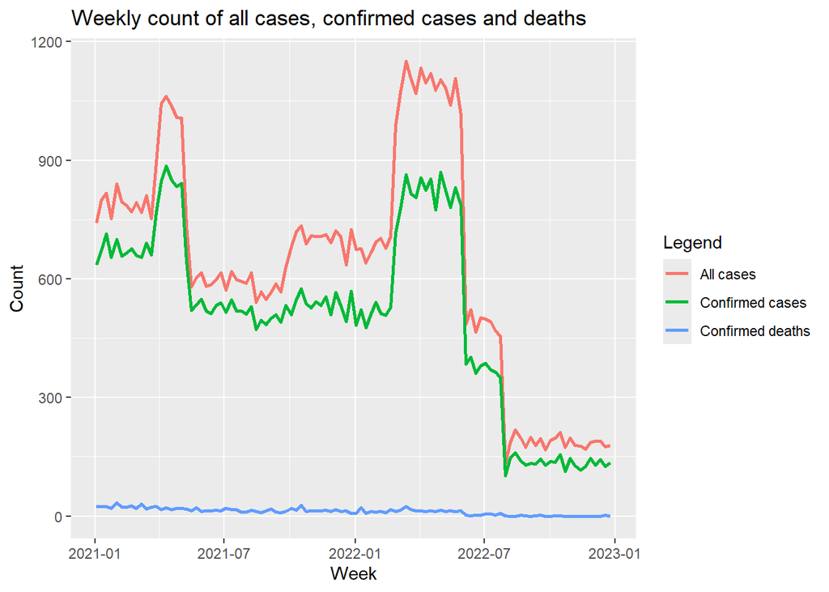

````markdown
```{r}
#Figure 1
#Aggregate the data to get the weekly count of all cases, confirmed cases and deaths
weekly_data <- subdf |>
  dplyr::group_by(week) |>
  dplyr::summarise(count = dplyr::n(),
                   confirmed_count = sum(confirmed == "1"),
                   death_count = sum(death == "1"))

#Plot the weekly count of all cases, confirmed cases and deaths
weekly_data |>
  ggplot2::ggplot(ggplot2::aes(x = week)) +
  ggplot2::geom_line(ggplot2::aes(y = count,
                                  color = "All cases"),
                     size = 1) +
  ggplot2::geom_line(ggplot2::aes(y = confirmed_count,
                                  color = "Confirmed cases"),
                     size = 1) +
  ggplot2::geom_line(ggplot2::aes(y = death_count,
                                  color = "Confirmed deaths"),
                     size = 1) +
  ggplot2::labs(title = "Weekly count of all cases, confirmed cases and deaths",
                x     = "Week",
                y     = "Count",
                color = "Legend")
```
````

**Tip**

- see [`fig-cap`](https://quarto.org/docs/computations/execution-options.html#caption-and-alt-text) option to add a caption to a figure generated by an executable code chunk;

## 5 Present statistical models and results

- Implement a logistic regression model based on the description provided in the Quarto notebook;
- Display the code chunk with your R implementation of the logistic regression (and only display this code chunk) in the rendered MS Word document.

````markdown
```{r}
#Logistic regression model
```
````

#### Table 3

- Create a table summarizing the odds ratios from the logistic regression model;
- Add a caption to the table.

````markdown
```{r}
#Table 3
```
````

**Tip**

- See `gtsummary` documentation for creating [formatted tables of regression model results](https://www.danieldsjoberg.com/gtsummary/articles/tbl_regression.html)

Ready to take it further? Once you have completed this exercise, you can add dynamic elements to your report ⭐⭐.